# final

##### Finally, we will use the RandomForestClassifier to determine which sector ETFs have the most impact among other sector ETFs for each individual ETF.

```python
from sklearn.ensemble.forest import RandomForestClassifier
```

```python
from sklearn.model_selection import train_test_split
```

```python
from sklearn.metrics import accuracy_score
```

```python
y = pd.cut(df_merged['xly'], bins=[-np.inf, df_merged['xly'].median(), np.inf], labels=[0, 1])
x = df_merged[['xlp','xlv', 'xlre','xlk', 'xli', 'xlf', 'xle', 'xlc', 'xlb']]
model_RF = RandomForestClassifier(max_depth=3)
model_RF.fit(x,y)
```

```
RandomForestClassifier(bootstrap=True, class_weight=None, criterion='gini',
            max_depth=3, max_features='auto', max_leaf_nodes=None,
            min_impurity_decrease=0.0, min_impurity_split=None,
            min_samples_leaf=1, min_samples_split=2,
            min_weight_fraction_leaf=0.0, n_estimators=10, n_jobs=None,
            oob_score=False, random_state=None, verbose=0,
            warm_start=False)
```

```python
explanatory_vars = model_RF.feature_importances_
```

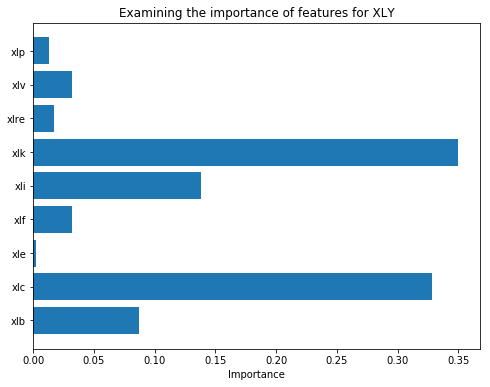

```python
fig, ax = plt.subplots(figsize=(8, 6))
y_pos = range(len(explanatory_vars))
ax.barh(y_pos, explanatory_vars, align='center')
ax.set_yticks(y_pos)
ax.set_yticklabels(x.columns)
ax.invert_yaxis()
ax.set_xlabel('Importance')
ax.set_title('Examining the importance of features for XLY')

plt.show()
```

```python
y = pd.cut(df_merged['xlp'], bins=[-np.inf, df_merged['xlp'].median(), np.inf], labels=[0, 1])
x = df_merged[['xly','xlv', 'xlre','xlk', 'xli', 'xlf', 'xle', 'xlc', 'xlb']]
model_RF = RandomForestClassifier(max_depth=3)
model_RF.fit(x,y)
```

```
RandomForestClassifier(bootstrap=True, class_weight=None, criterion='gini',
            max_depth=3, max_features='auto', max_leaf_nodes=None,
            min_impurity_decrease=0.0, min_impurity_split=None,
            min_samples_leaf=1, min_samples_split=2,
            min_weight_fraction_leaf=0.0, n_estimators=10, n_jobs=None,
            oob_score=False, random_state=None, verbose=0,
            warm_start=False)
```

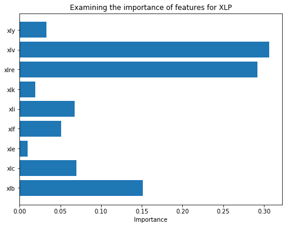

```python
explanatory_vars = model_RF.feature_importances_
fig, ax = plt.subplots(figsize=(8, 6))
y_pos = range(len(explanatory_vars))
ax.barh(y_pos, explanatory_vars, align='center')
ax.set_yticks(y_pos)
ax.set_yticklabels(x.columns)
ax.invert_yaxis()
ax.set_xlabel('Importance')
ax.set_title('Examining the importance of features for XLP')

plt.show()
```

##### Looking at it this way, we can see that there are several combinations of sector ETFs with stronger correlations. For example, XLV (Health Care Select Sector) has the strongest influence on XLP (Consumer Staples Select Sector). This is a very intuitive and easy-to-understand result.

### Insight and Conclusion

##### In this tutorial, we investigated how the daily price movements of 10 different sector ETFs are influenced by the movements of 5 indices, gold, bonds, interest rates, the US dollar index, and the euro index. However, we were unable to achieve the expected results. The main issue was the limited number of explanatory variables. Additionally, although we needed to consider factors such as inflation indicators, there was no way to predict their short-term movements. The most commonly used inflation indicator, CPI, is updated only once a month, making it impossible to incorporate it into our analysis. As mentioned earlier, the unavailability of datasets on trading volumes and hourly price movements was also a contributing factor that hindered our initial analysis.

##### In summary, the shorter the term price movement, the more random the walk tends to be. Analyzing financial markets is a challenging task due to their complexity, as they are influenced by numerous factors. Nonetheless, we did recognize a correlation between the sector ETFs, which is a positive outcome. Therefore, it is still appropriate to examine the supply and demand of other stocks to a certain extent in order to predict short-term price movements.

##### In the future, if we have another opportunity to analyze the financial markets, we would like to focus on long-term price movements as they are relatively easier to obtain data sets for.

### Resources

##### This explains how to deal with the feature importances of Random Forest Classifier.

##### https://mljar.com/blog/feature-importance-in-random-forest/

##### The datasets that I used are from investing.com and finance.yahoo.com